# R Notebook

```r
library(tidyverse)
library(janitor)
library(infer)
ames <- read_csv("data/ames.csv") %>% clean_names()
```

[output not shown]

Data exploring

```r
head(ames)
```

| order | pid | ms_sub_class | ms_zoning | lot_frontage | lot_area | street | alley | lot_shape | land_contour | utilities | lot_config | land_slope | neighborhood | condition_1 | condition_2 | bldg_type | house_style | overall_qual | overall_cond | year_built | year_remod_add | roof_style | roof_matl | exterior_1st | exterior_2nd | mas_vnr_type | mas_vnr_area | exter_qual | exter_cond | … |
| --- | --- | --- | --- | --- | --- | --- | --- | --- | --- | --- | --- | --- | --- | --- | --- | --- | --- | --- | --- | --- | --- | --- | --- | --- | --- | --- | --- | --- | --- | --- |
| 1 | 526301100 | 20 | RL | 141 | 31770 | Pave | NA | IR1 | Lvl | AllPub | Corner | Gtl | NAmes | Norm | Norm | 1Fam | 1Story | 6 | 5 | 1960 | 1960 | Hip | CompShg | BrkFace | Plywood | Stone | 112 | TA | TA | … |
| 2 | 526350040 | 20 | RH | 80 | 11622 | Pave | NA | Reg | Lvl | AllPub | Inside | Gtl | NAmes | Feedr | Norm | 1Fam | 1Story | 5 | 6 | 1961 | 1961 | Gable | CompShg | VinylSd | VinylSd | None | 0 | TA | TA | … |
| 3 | 526351010 | 20 | RL | 81 | 14267 | Pave | NA | IR1 | Lvl | AllPub | Corner | Gtl | NAmes | Norm | Norm | 1Fam | 1Story | 6 | 6 | 1958 | 1958 | Hip | CompShg | Wd Sdng | Wd Sdng | BrkFace | 108 | TA | TA | … |
| 4 | 526353030 | 20 | RL | 93 | 11160 | Pave | NA | Reg | Lvl | AllPub | Corner | Gtl | NAmes | Norm | Norm | 1Fam | 1Story | 7 | 5 | 1968 | 1968 | Hip | CompShg | BrkFace | BrkFace | None | 0 | Gd | TA | … |
| 5 | 527105010 | 60 | RL | 74 | 13830 | Pave | NA | IR1 | Lvl | AllPub | Inside | Gtl | Gilbert | Norm | Norm | 1Fam | 2Story | 5 | 5 | 1997 | 1998 | Gable | CompShg | VinylSd | VinylSd | None | 0 | TA | TA | … |
| 6 | 527105030 | 60 | RL | 78 | 9978 | Pave | NA | IR1 | Lvl | AllPub | Inside | Gtl | Gilbert | Norm | Norm | 1Fam | 2Story | 6 | 6 | 1998 | 1998 | Gable | CompShg | VinylSd | VinylSd | BrkFace | 20 | TA | TA | … |

```r
dim(ames)
```

```
[1] 2930   82
```

```r
glimpse(ames)
```

```
Rows: 2,930
Columns: 82
$ order           <dbl> 1, 2, 3, 4, 5, 6, 7, 8, 9, 10, 11, 12, 13, 14, 15, 1…
$ pid             <dbl> 526301100, 526350040, 526351010, 526353030, 52710501…
$ ms_sub_class    <dbl> 20, 20, 20, 20, 60, 60, 120, 120, 120, 60, 60, 20, 6…
$ ms_zoning       <chr> "RL", "RH", "RL", "RL", "RL", "RL", "RL", "RL", "RL"…
$ lot_frontage    <dbl> 141, 80, 81, 93, 74, 78, 41, 43, 39, 60, 75, NA, 63,…
$ lot_area        <dbl> 31770, 11622, 14267, 11160, 13830, 9978, 4920, 5005,…
$ street          <chr> "Pave", "Pave", "Pave", "Pave", "Pave", "Pave", "Pav…
$ alley           <chr> NA, NA, NA, NA, NA, NA, NA, NA, NA, NA, NA, NA, NA, …
$ lot_shape       <chr> "IR1", "Reg", "IR1", "Reg", "IR1", "IR1", "Reg", "IR…
$ land_contour    <chr> "Lvl", "Lvl", "Lvl", "Lvl", "Lvl", "Lvl", "Lvl", "HL…
$ utilities       <chr> "AllPub", "AllPub", "AllPub", "AllPub", "AllPub", "A…
$ lot_config      <chr> "Corner", "Inside", "Corner", "Corner", "Inside", "I…
$ land_slope      <chr> "Gtl", "Gtl", "Gtl", "Gtl", "Gtl", "Gtl", "Gtl", "Gt…
```

[output cut: 69 more lines]

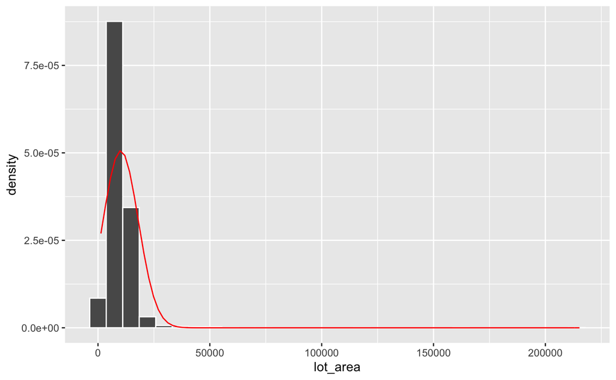

```r
ames %>%
  select(lot_area) %>%
  ggplot() +
  aes(x = lot_area) +
  geom_histogram(aes(y = ..density..), col = "white", bins = 30) +
  stat_function( fun = dnorm,
    args = list(
      mean = mean(ames$lot_area),
      sd = sd(ames$lot_area)
    ),
    col = "red"
  )
```

It is highly right skewed and there is no data below zero as it is area and the lowest is zero which is impossible for area to be. Most data concentrated on the lower numbers.

Compute and visualise a bootstrap sampling distribution for the mean(lot_area) of the sold houses.

```r
boostrap_resample_200 <- ames %>%
  rep_sample_n(size = 200, replace = TRUE, reps = 5000) %>%
  summarise(
    mean_lot_area = mean(lot_area),
  )
boostrap_resample_200
```

| replicate | mean_lot_area |
| --- | --- |
| 1 | 9470.705 |
| 2 | 10665.950 |
| 3 | 9243.450 |
| 4 | 9909.575 |
| 5 | 10036.540 |
| 6 | 9719.035 |
| 7 | 10511.735 |
| 8 | 9911.785 |
| 9 | 10117.925 |
| 10 | 9644.250 |

[output cut: 990 more lines]

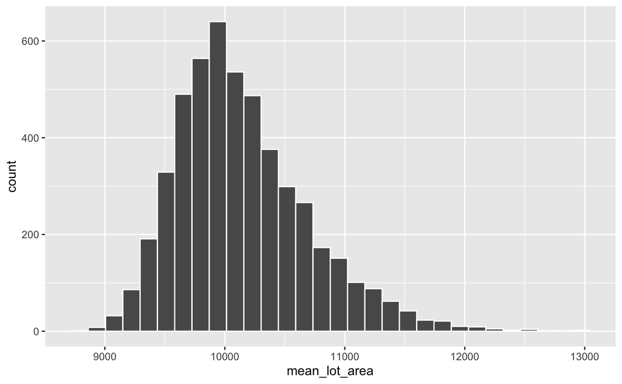

```r
boostrap_resample_200 %>%
  ggplot(aes(x = mean_lot_area)) +
  geom_histogram(col = "white", bins = 30)
```

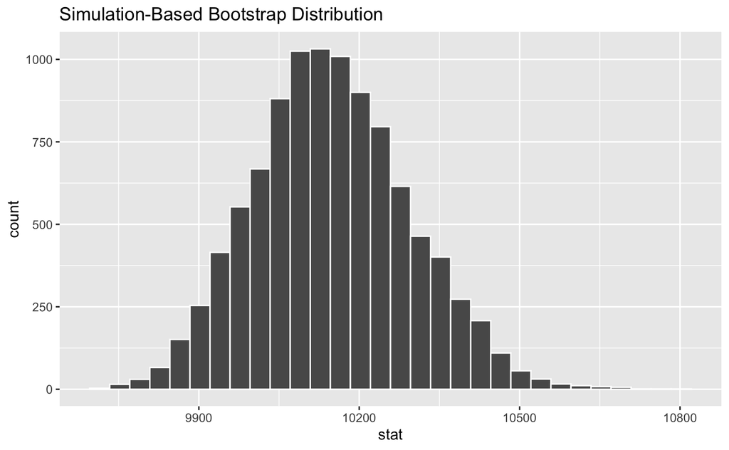

```r
bootstrap_distn <- ames %>%
  specify(response = lot_area) %>%
  generate(reps = 10000, type = "bootstrap") %>%
  calculate(stat = "mean")

bootstrap_distn %>%
  visualise(bins = 30)
```

```r
ames %>%
  summarise(mean_lot_area = mean(lot_area))
```

| mean_lot_area |
| --- |
| 10147.92 |

Use your bootstrap distribution to calculate a 95% CI for mean(lot_area), and visualise it on the distribution

```r
infer_resample <- ames %>%
  specify(response = lot_area) %>%
  generate(reps = 5000, type = "bootstrap") %>%
  calculate(stat = "mean")

infer_ci_95 <- infer_resample %>%
  get_ci(level = 0.95, type = "percentile")
```

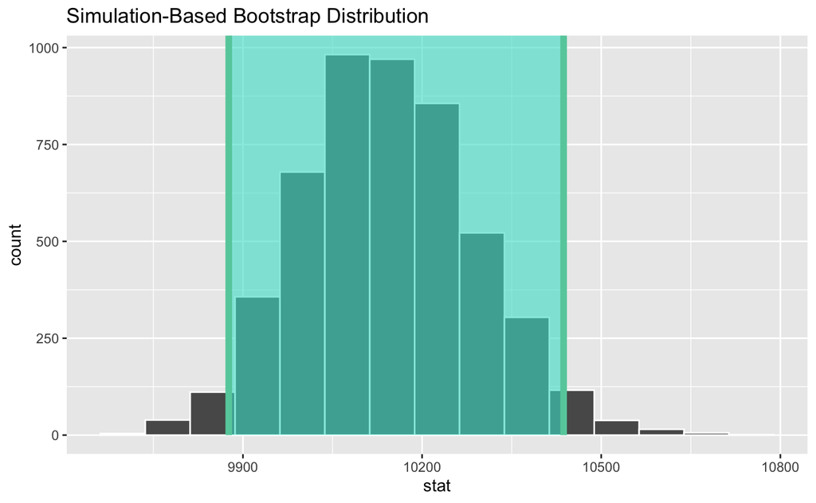

```r
infer_resample %>%
  visualise() +
  shade_ci(endpoints = infer_ci_95)
```

You would like to know the mean(lot_area) of the sold houses with higher confidence. Calculate the 99% CI for this variable (you can re-use your bootstrap distribution from above). Is it narrower or broader than the 95% CI? Does that make sense?

[output not shown]

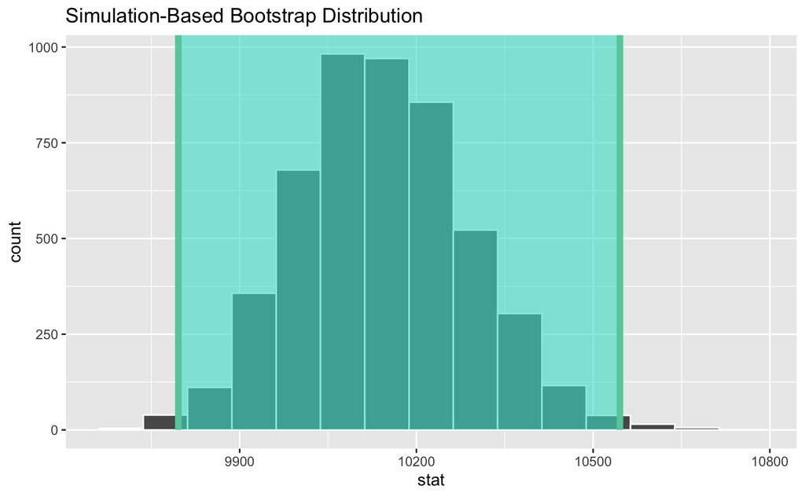

```r
infer_resample %>%
  visualise() +
  shade_ci(endpoints = infer_ci_99)
```

CI in 99% is broader than in 95%.

```r
infer_resample %>%
  filter(stat >= infer_ci_99$lower_ci, stat <= infer_ci_99$upper_ci) %>%
  summarise(mean = mean(stat))
```

| mean |
| --- |
| 10142.67 |

Calculate the point estimate of the mean(lot_area)

```r
infer_resample %>%
  summarise(mean(stat))
```

| mean(stat) |
| --- |
| 10143.1 |

Calculate a point estimate and 95% CI for the proportion of houses in the data built before 1920. Does the number of reps you use matter? [Investigate reps from 200 up to 50000 , memory of your laptop permitting].

[Hint - the current implementation of calculate(stat = “prop”) in infer is slow! You can get around this by treating the mean in this way: add a new column via mutate(before_1920 = as.numeric(year_built < 1920)) and then calculate(stat = “mean”) on this new column]

```r
ames_before_1920 <- ames %>%
  mutate(before_1920 = as.numeric(year_built < 1920))

ames_before_1920
```

| order | pid | ms_sub_class | ms_zoning | lot_frontage | lot_area | street | alley | lot_shape | land_contour | utilities | lot_config | land_slope | neighborhood | condition_1 | condition_2 | bldg_type | house_style | overall_qual | overall_cond | year_built | year_remod_add | roof_style | roof_matl | exterior_1st | exterior_2nd | mas_vnr_type | mas_vnr_area | exter_qual | exter_cond | … |
| --- | --- | --- | --- | --- | --- | --- | --- | --- | --- | --- | --- | --- | --- | --- | --- | --- | --- | --- | --- | --- | --- | --- | --- | --- | --- | --- | --- | --- | --- | --- |
| 1 | 526301100 | 20 | RL | 141 | 31770 | Pave | NA | IR1 | Lvl | AllPub | Corner | Gtl | NAmes | Norm | Norm | 1Fam | 1Story | 6 | 5 | 1960 | 1960 | Hip | CompShg | BrkFace | Plywood | Stone | 112 | TA | TA | … |
| 2 | 526350040 | 20 | RH | 80 | 11622 | Pave | NA | Reg | Lvl | AllPub | Inside | Gtl | NAmes | Feedr | Norm | 1Fam | 1Story | 5 | 6 | 1961 | 1961 | Gable | CompShg | VinylSd | VinylSd | None | 0 | TA | TA | … |
| 3 | 526351010 | 20 | RL | 81 | 14267 | Pave | NA | IR1 | Lvl | AllPub | Corner | Gtl | NAmes | Norm | Norm | 1Fam | 1Story | 6 | 6 | 1958 | 1958 | Hip | CompShg | Wd Sdng | Wd Sdng | BrkFace | 108 | TA | TA | … |
| 4 | 526353030 | 20 | RL | 93 | 11160 | Pave | NA | Reg | Lvl | AllPub | Corner | Gtl | NAmes | Norm | Norm | 1Fam | 1Story | 7 | 5 | 1968 | 1968 | Hip | CompShg | BrkFace | BrkFace | None | 0 | Gd | TA | … |
| 5 | 527105010 | 60 | RL | 74 | 13830 | Pave | NA | IR1 | Lvl | AllPub | Inside | Gtl | Gilbert | Norm | Norm | 1Fam | 2Story | 5 | 5 | 1997 | 1998 | Gable | CompShg | VinylSd | VinylSd | None | 0 | TA | TA | … |
| 6 | 527105030 | 60 | RL | 78 | 9978 | Pave | NA | IR1 | Lvl | AllPub | Inside | Gtl | Gilbert | Norm | Norm | 1Fam | 2Story | 6 | 6 | 1998 | 1998 | Gable | CompShg | VinylSd | VinylSd | BrkFace | 20 | TA | TA | … |
| 7 | 527127150 | 120 | RL | 41 | 4920 | Pave | NA | Reg | Lvl | AllPub | Inside | Gtl | StoneBr | Norm | Norm | TwnhsE | 1Story | 8 | 5 | 2001 | 2001 | Gable | CompShg | CemntBd | CmentBd | None | 0 | Gd | TA | … |
| 8 | 527145080 | 120 | RL | 43 | 5005 | Pave | NA | IR1 | HLS | AllPub | Inside | Gtl | StoneBr | Norm | Norm | TwnhsE | 1Story | 8 | 5 | 1992 | 1992 | Gable | CompShg | HdBoard | HdBoard | None | 0 | Gd | TA | … |
| 9 | 527146030 | 120 | RL | 39 | 5389 | Pave | NA | IR1 | Lvl | AllPub | Inside | Gtl | StoneBr | Norm | Norm | TwnhsE | 1Story | 8 | 5 | 1995 | 1996 | Gable | CompShg | CemntBd | CmentBd | None | 0 | Gd | TA | … |
| 10 | 527162130 | 60 | RL | 60 | 7500 | Pave | NA | Reg | Lvl | AllPub | Inside | Gtl | Gilbert | Norm | Norm | 1Fam | 2Story | 7 | 5 | 1999 | 1999 | Gable | CompShg | VinylSd | VinylSd | None | 0 | TA | TA | … |

[output cut: 990 more lines]

[output not shown]

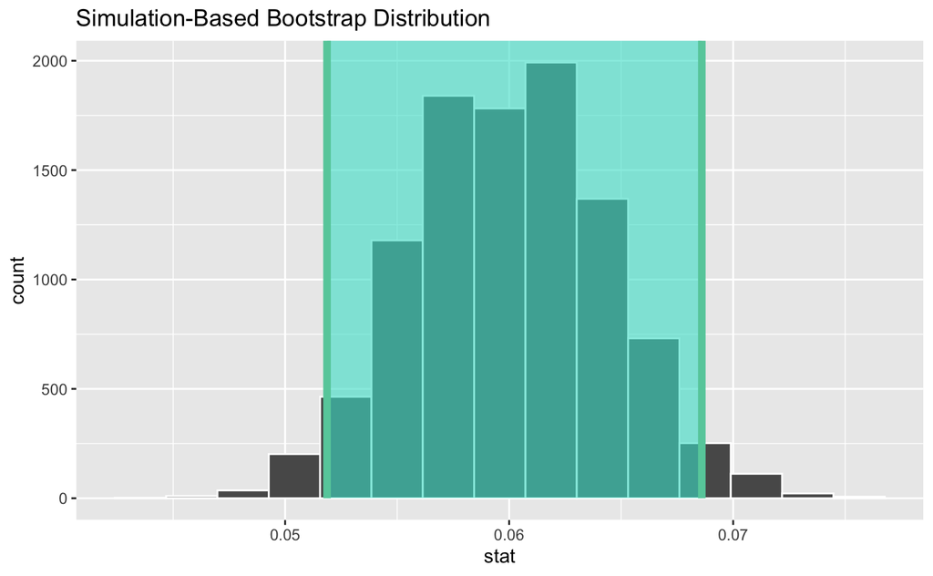

```r
infer_resample_1920 %>%
  visualise() +
  shade_ci(endpoints = infer_ci_95_1920)
```

```r
infer_resample_1920 %>%
  summarise(mean(stat))
```

| mean(stat) |
| --- |
| 0.06001908 |